# Risk Factor Analysis

## Outcome Variable

**Outcome Variable:** sstunted

## Predictor Variables

**Intervention Variable:** gagebrth

**Adjustment Set:**

unadjusted

## Stratifying Variables

The analysis was stratified on these variable(s):

- agecat
- studyid
- country

## Data Summary

| agecat | studyid | country | A | n | nA | nAY0 | nAY1 |
| --- | --- | --- | --- | --- | --- | --- | --- |
| Birth | ki1000108-CMC-V-BCS-2002 | INDIA | [273-287) | 90 | 35 | 33 | 2 |
| Birth | ki1000108-CMC-V-BCS-2002 | INDIA | <259 | 90 | 7 | 7 | 0 |
| Birth | ki1000108-CMC-V-BCS-2002 | INDIA | [259-273) | 90 | 22 | 22 | 0 |
| Birth | ki1000108-CMC-V-BCS-2002 | INDIA | >=287 | 90 | 26 | 25 | 1 |
| Birth | ki1000108-IRC | INDIA | [273-287) | 369 | 155 | 151 | 4 |
| Birth | ki1000108-IRC | INDIA | <259 | 369 | 36 | 33 | 3 |
| Birth | ki1000108-IRC | INDIA | [259-273) | 369 | 87 | 85 | 2 |
| Birth | ki1000108-IRC | INDIA | >=287 | 369 | 91 | 85 | 6 |
| Birth | ki1000109-EE | PAKISTAN | [273-287) | 2 | 0 | 0 | 0 |
| Birth | ki1000109-EE | PAKISTAN | <259 | 2 | 1 | 1 | 0 |
| Birth | ki1000109-EE | PAKISTAN | [259-273) | 2 | 1 | 1 | 0 |
| Birth | ki1000109-EE | PAKISTAN | >=287 | 2 | 0 | 0 | 0 |
| Birth | ki1000304b-SAS-CompFeed | INDIA | [273-287) | 70 | 0 | 0 | 0 |
| Birth | ki1000304b-SAS-CompFeed | INDIA | <259 | 70 | 55 | 51 | 4 |
| Birth | ki1000304b-SAS-CompFeed | INDIA | [259-273) | 70 | 15 | 15 | 0 |
| Birth | ki1000304b-SAS-CompFeed | INDIA | >=287 | 70 | 0 | 0 | 0 |
| Birth | ki1017093c-NIH-Crypto | BANGLADESH | [273-287) | 27 | 12 | 12 | 0 |
| Birth | ki1017093c-NIH-Crypto | BANGLADESH | <259 | 27 | 3 | 3 | 0 |
| Birth | ki1017093c-NIH-Crypto | BANGLADESH | [259-273) | 27 | 11 | 10 | 1 |
| Birth | ki1017093c-NIH-Crypto | BANGLADESH | >=287 | 27 | 1 | 1 | 0 |
| Birth | ki1101329-Keneba | GAMBIA | [273-287) | 1515 | 592 | 586 | 6 |
| Birth | ki1101329-Keneba | GAMBIA | <259 | 1515 | 161 | 149 | 12 |
| Birth | ki1101329-Keneba | GAMBIA | [259-273) | 1515 | 592 | 583 | 9 |
| Birth | ki1101329-Keneba | GAMBIA | >=287 | 1515 | 170 | 168 | 2 |
| Birth | ki1119695-PROBIT | BELARUS | [273-287) | 6779 | 4858 | 4857 | 1 |
| Birth | ki1119695-PROBIT | BELARUS | <259 | 6779 | 0 | 0 | 0 |
| Birth | ki1119695-PROBIT | BELARUS | [259-273) | 6779 | 1403 | 1399 | 4 |
| Birth | ki1119695-PROBIT | BELARUS | >=287 | 6779 | 518 | 518 | 0 |
| Birth | ki1135781-COHORTS | GUATEMALA | [273-287) | 290 | 114 | 114 | 0 |
| Birth | ki1135781-COHORTS | GUATEMALA | <259 | 290 | 49 | 47 | 2 |

[output cut: 306 more lines]

The following strata were considered:

- agecat: 12 months, studyid: ki1000108-CMC-V-BCS-2002, country: INDIA
- agecat: 12 months, studyid: ki1000108-IRC, country: INDIA
- agecat: 12 months, studyid: ki1000109-EE, country: PAKISTAN
- agecat: 12 months, studyid: ki1000304b-SAS-CompFeed, country: INDIA
- agecat: 12 months, studyid: ki1017093c-NIH-Crypto, country: BANGLADESH
- agecat: 12 months, studyid: ki1066203-TanzaniaChild2, country: TANZANIA, UNITED REPUBLIC OF
- agecat: 12 months, studyid: ki1101329-Keneba, country: GAMBIA
- agecat: 12 months, studyid: ki1113344-GMS-Nepal, country: NEPAL
- agecat: 12 months, studyid: ki1119695-PROBIT, country: BELARUS
- agecat: 12 months, studyid: ki1135781-COHORTS, country: GUATEMALA
- agecat: 12 months, studyid: ki1135781-COHORTS, country: INDIA
- agecat: 12 months, studyid: ki1135781-COHORTS, country: PHILIPPINES
- agecat: 12 months, studyid: kiGH5241-JiVitA-3, country: BANGLADESH
- agecat: 18 months, studyid: ki1000108-CMC-V-BCS-2002, country: INDIA
- agecat: 18 months, studyid: ki1000108-IRC, country: INDIA
- agecat: 18 months, studyid: ki1000109-EE, country: PAKISTAN
- agecat: 18 months, studyid: ki1000304b-SAS-CompFeed, country: INDIA
- agecat: 18 months, studyid: ki1017093c-NIH-Crypto, country: BANGLADESH
- agecat: 18 months, studyid: ki1066203-TanzaniaChild2, country: TANZANIA, UNITED REPUBLIC OF
- agecat: 18 months, studyid: ki1101329-Keneba, country: GAMBIA
- agecat: 18 months, studyid: ki1113344-GMS-Nepal, country: NEPAL
- agecat: 18 months, studyid: ki1119695-PROBIT, country: BELARUS
- agecat: 18 months, studyid: ki1135781-COHORTS, country: GUATEMALA
- agecat: 18 months, studyid: ki1135781-COHORTS, country: PHILIPPINES
- agecat: 24 months, studyid: ki1000108-CMC-V-BCS-2002, country: INDIA
- agecat: 24 months, studyid: ki1000108-IRC, country: INDIA
- agecat: 24 months, studyid: ki1017093c-NIH-Crypto, country: BANGLADESH
- agecat: 24 months, studyid: ki1066203-TanzaniaChild2, country: TANZANIA, UNITED REPUBLIC OF
- agecat: 24 months, studyid: ki1101329-Keneba, country: GAMBIA
- agecat: 24 months, studyid: ki1113344-GMS-Nepal, country: NEPAL
- agecat: 24 months, studyid: ki1119695-PROBIT, country: BELARUS
- agecat: 24 months, studyid: ki1135781-COHORTS, country: GUATEMALA
- agecat: 24 months, studyid: ki1135781-COHORTS, country: INDIA
- agecat: 24 months, studyid: ki1135781-COHORTS, country: PHILIPPINES
- agecat: 24 months, studyid: kiGH5241-JiVitA-3, country: BANGLADESH
- agecat: 3 months, studyid: ki1000108-CMC-V-BCS-2002, country: INDIA
- agecat: 3 months, studyid: ki1000108-IRC, country: INDIA
- agecat: 3 months, studyid: ki1000109-EE, country: PAKISTAN
- agecat: 3 months, studyid: ki1000304b-SAS-CompFeed, country: INDIA
- agecat: 3 months, studyid: ki1017093c-NIH-Crypto, country: BANGLADESH
- agecat: 3 months, studyid: ki1066203-TanzaniaChild2, country: TANZANIA, UNITED REPUBLIC OF
- agecat: 3 months, studyid: ki1101329-Keneba, country: GAMBIA
- agecat: 3 months, studyid: ki1113344-GMS-Nepal, country: NEPAL
- agecat: 3 months, studyid: ki1119695-PROBIT, country: BELARUS
- agecat: 3 months, studyid: ki1135781-COHORTS, country: GUATEMALA
- agecat: 3 months, studyid: ki1135781-COHORTS, country: INDIA
- agecat: 3 months, studyid: ki1135781-COHORTS, country: PHILIPPINES
- agecat: 3 months, studyid: kiGH5241-JiVitA-3, country: BANGLADESH
- agecat: 6 months, studyid: ki1000108-CMC-V-BCS-2002, country: INDIA
- agecat: 6 months, studyid: ki1000108-IRC, country: INDIA
- agecat: 6 months, studyid: ki1000109-EE, country: PAKISTAN
- agecat: 6 months, studyid: ki1000304b-SAS-CompFeed, country: INDIA
- agecat: 6 months, studyid: ki1017093c-NIH-Crypto, country: BANGLADESH
- agecat: 6 months, studyid: ki1066203-TanzaniaChild2, country: TANZANIA, UNITED REPUBLIC OF
- agecat: 6 months, studyid: ki1101329-Keneba, country: GAMBIA
- agecat: 6 months, studyid: ki1113344-GMS-Nepal, country: NEPAL
- agecat: 6 months, studyid: ki1119695-PROBIT, country: BELARUS
- agecat: 6 months, studyid: ki1135781-COHORTS, country: GUATEMALA
- agecat: 6 months, studyid: ki1135781-COHORTS, country: INDIA
- agecat: 6 months, studyid: ki1135781-COHORTS, country: PHILIPPINES
- agecat: 6 months, studyid: kiGH5241-JiVitA-3, country: BANGLADESH
- agecat: 9 months, studyid: ki1000108-CMC-V-BCS-2002, country: INDIA
- agecat: 9 months, studyid: ki1000108-IRC, country: INDIA
- agecat: 9 months, studyid: ki1000109-EE, country: PAKISTAN
- agecat: 9 months, studyid: ki1000304b-SAS-CompFeed, country: INDIA
- agecat: 9 months, studyid: ki1017093c-NIH-Crypto, country: BANGLADESH
- agecat: 9 months, studyid: ki1066203-TanzaniaChild2, country: TANZANIA, UNITED REPUBLIC OF
- agecat: 9 months, studyid: ki1101329-Keneba, country: GAMBIA
- agecat: 9 months, studyid: ki1113344-GMS-Nepal, country: NEPAL
- agecat: 9 months, studyid: ki1119695-PROBIT, country: BELARUS
- agecat: 9 months, studyid: ki1135781-COHORTS, country: GUATEMALA
- agecat: 9 months, studyid: ki1135781-COHORTS, country: INDIA
- agecat: 9 months, studyid: ki1135781-COHORTS, country: PHILIPPINES
- agecat: Birth, studyid: ki1000108-CMC-V-BCS-2002, country: INDIA
- agecat: Birth, studyid: ki1000108-IRC, country: INDIA
- agecat: Birth, studyid: ki1000109-EE, country: PAKISTAN
- agecat: Birth, studyid: ki1000304b-SAS-CompFeed, country: INDIA
- agecat: Birth, studyid: ki1017093c-NIH-Crypto, country: BANGLADESH
- agecat: Birth, studyid: ki1101329-Keneba, country: GAMBIA
- agecat: Birth, studyid: ki1119695-PROBIT, country: BELARUS
- agecat: Birth, studyid: ki1135781-COHORTS, country: GUATEMALA
- agecat: Birth, studyid: ki1135781-COHORTS, country: INDIA
- agecat: Birth, studyid: ki1135781-COHORTS, country: PHILIPPINES
- agecat: Birth, studyid: kiGH5241-JiVitA-3, country: BANGLADESH

### Dropped Strata

Some strata were dropped due to rare outcomes:

- agecat: Birth, studyid: ki1000108-CMC-V-BCS-2002, country: INDIA
- agecat: Birth, studyid: ki1000108-IRC, country: INDIA
- agecat: Birth, studyid: ki1000109-EE, country: PAKISTAN
- agecat: Birth, studyid: ki1000304b-SAS-CompFeed, country: INDIA
- agecat: Birth, studyid: ki1017093c-NIH-Crypto, country: BANGLADESH
- agecat: Birth, studyid: ki1101329-Keneba, country: GAMBIA
- agecat: Birth, studyid: ki1119695-PROBIT, country: BELARUS
- agecat: Birth, studyid: ki1135781-COHORTS, country: GUATEMALA
- agecat: Birth, studyid: ki1135781-COHORTS, country: PHILIPPINES
- agecat: 3 months, studyid: ki1000109-EE, country: PAKISTAN
- agecat: 3 months, studyid: ki1000304b-SAS-CompFeed, country: INDIA
- agecat: 3 months, studyid: ki1017093c-NIH-Crypto, country: BANGLADESH
- agecat: 3 months, studyid: ki1066203-TanzaniaChild2, country: TANZANIA, UNITED REPUBLIC OF
- agecat: 3 months, studyid: ki1101329-Keneba, country: GAMBIA
- agecat: 3 months, studyid: ki1113344-GMS-Nepal, country: NEPAL
- agecat: 3 months, studyid: ki1119695-PROBIT, country: BELARUS
- agecat: 6 months, studyid: ki1000108-IRC, country: INDIA
- agecat: 6 months, studyid: ki1000109-EE, country: PAKISTAN
- agecat: 6 months, studyid: ki1000304b-SAS-CompFeed, country: INDIA
- agecat: 6 months, studyid: ki1017093c-NIH-Crypto, country: BANGLADESH
- agecat: 6 months, studyid: ki1066203-TanzaniaChild2, country: TANZANIA, UNITED REPUBLIC OF
- agecat: 6 months, studyid: ki1101329-Keneba, country: GAMBIA
- agecat: 6 months, studyid: ki1113344-GMS-Nepal, country: NEPAL
- agecat: 6 months, studyid: ki1119695-PROBIT, country: BELARUS
- agecat: 9 months, studyid: ki1000108-IRC, country: INDIA
- agecat: 9 months, studyid: ki1000109-EE, country: PAKISTAN
- agecat: 9 months, studyid: ki1000304b-SAS-CompFeed, country: INDIA
- agecat: 9 months, studyid: ki1017093c-NIH-Crypto, country: BANGLADESH
- agecat: 9 months, studyid: ki1066203-TanzaniaChild2, country: TANZANIA, UNITED REPUBLIC OF
- agecat: 9 months, studyid: ki1113344-GMS-Nepal, country: NEPAL
- agecat: 9 months, studyid: ki1119695-PROBIT, country: BELARUS
- agecat: 12 months, studyid: ki1000108-IRC, country: INDIA
- agecat: 12 months, studyid: ki1000109-EE, country: PAKISTAN
- agecat: 12 months, studyid: ki1000304b-SAS-CompFeed, country: INDIA
- agecat: 12 months, studyid: ki1017093c-NIH-Crypto, country: BANGLADESH
- agecat: 12 months, studyid: ki1113344-GMS-Nepal, country: NEPAL
- agecat: 12 months, studyid: ki1119695-PROBIT, country: BELARUS
- agecat: 18 months, studyid: ki1000109-EE, country: PAKISTAN
- agecat: 18 months, studyid: ki1000304b-SAS-CompFeed, country: INDIA
- agecat: 18 months, studyid: ki1017093c-NIH-Crypto, country: BANGLADESH
- agecat: 18 months, studyid: ki1113344-GMS-Nepal, country: NEPAL
- agecat: 18 months, studyid: ki1119695-PROBIT, country: BELARUS
- agecat: 24 months, studyid: ki1017093c-NIH-Crypto, country: BANGLADESH
- agecat: 24 months, studyid: ki1066203-TanzaniaChild2, country: TANZANIA, UNITED REPUBLIC OF
- agecat: 24 months, studyid: ki1113344-GMS-Nepal, country: NEPAL
- agecat: 24 months, studyid: ki1119695-PROBIT, country: BELARUS

## Methods Detail

We’re interested in the causal parameters $E[Y_a]$ for all values of $a \in \mathcal{A}$. These parameters represent the mean outcome if, possibly contrary to fact, we intervened to set all units to have $A=a$. Under the randomization and positivity assumptions, these are identified by the statistical parameters $\psi_a=E_W[E_{Y|A,W}(Y|A=a,W)]$. In addition, we’re interested in the mean of $Y$, $E[Y]$ under no intervention (the observed mean). We will estimate these parameters by using SuperLearner to fit the relevant likelihood factors – $E_{Y|A,W}(Y|A=a,W)$ and $p(A=a|W)$, and then updating our likelihood fit using a joint TMLE.

For unadjusted analyses ($W=\{\}$), initial likelihoods were estimated using Lrnr_glm to estimate the simple $E(Y|A)$ and Lrnr_mean to estimate $p(A)$. For adjusted analyses, a small library containing Lrnr_glmnet, Lrnr_xgboost, and Lrnr_mean was used.

Having estimated these parameters, we will then use the delta method to estimate relative risks and attributable risks relative to a prespecified baseline level of $A$.

# Results Detail

## Results Plots

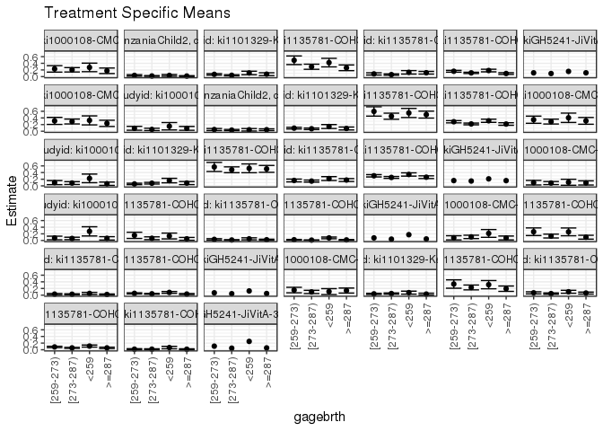

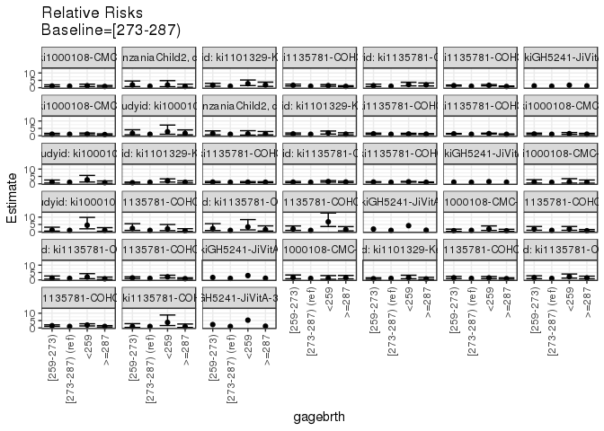

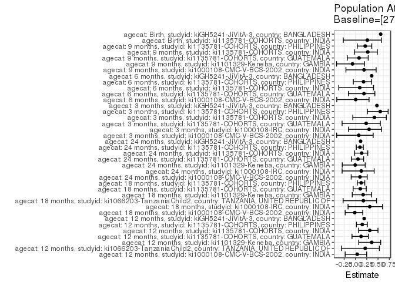

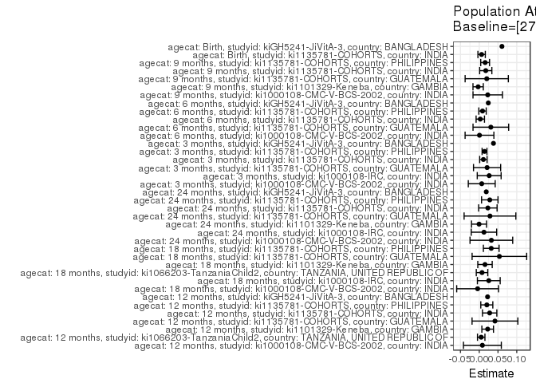

## Results Table

### Parameter: TSM

| agecat | studyid | country | intervention_level | baseline_level | estimate | ci_lower | ci_upper |
| --- | --- | --- | --- | --- | --- | --- | --- |
| Birth | ki1135781-COHORTS | INDIA | [273-287) | NA | 0.0176471 | 0.0062156 | 0.0290785 |
| Birth | ki1135781-COHORTS | INDIA | <259 | NA | 0.0662983 | 0.0300380 | 0.1025587 |
| Birth | ki1135781-COHORTS | INDIA | [259-273) | NA | 0.0173010 | 0.0022622 | 0.0323398 |
| Birth | ki1135781-COHORTS | INDIA | >=287 | NA | 0.0159744 | 0.0020794 | 0.0298695 |
| Birth | kiGH5241-JiVitA-3 | BANGLADESH | [273-287) | NA | 0.0477395 | NA | NA |
| Birth | kiGH5241-JiVitA-3 | BANGLADESH | <259 | NA | 0.2515528 | NA | NA |
| Birth | kiGH5241-JiVitA-3 | BANGLADESH | [259-273) | NA | 0.1084634 | NA | NA |
| Birth | kiGH5241-JiVitA-3 | BANGLADESH | >=287 | NA | 0.0559611 | NA | NA |
| 3 months | ki1000108-CMC-V-BCS-2002 | INDIA | [273-287) | NA | 0.0845070 | 0.0386910 | 0.1303231 |
| 3 months | ki1000108-CMC-V-BCS-2002 | INDIA | <259 | NA | 0.1086957 | 0.0186158 | 0.1987755 |
| 3 months | ki1000108-CMC-V-BCS-2002 | INDIA | [259-273) | NA | 0.0958904 | 0.0282472 | 0.1635337 |
| 3 months | ki1000108-CMC-V-BCS-2002 | INDIA | >=287 | NA | 0.0886076 | 0.0258506 | 0.1513646 |
| 3 months | ki1000108-IRC | INDIA | [273-287) | NA | 0.0613497 | 0.0244626 | 0.0982368 |
| 3 months | ki1000108-IRC | INDIA | <259 | NA | 0.2750000 | 0.1364472 | 0.4135528 |
| 3 months | ki1000108-IRC | INDIA | [259-273) | NA | 0.0760870 | 0.0218386 | 0.1303353 |
| 3 months | ki1000108-IRC | INDIA | >=287 | NA | 0.0652174 | 0.0146986 | 0.1157362 |
| 3 months | ki1135781-COHORTS | GUATEMALA | [273-287) | NA | 0.0671642 | 0.0247232 | 0.1096051 |
| 3 months | ki1135781-COHORTS | GUATEMALA | <259 | NA | 0.1355932 | 0.0481114 | 0.2230751 |
| 3 months | ki1135781-COHORTS | GUATEMALA | [259-273) | NA | 0.1551724 | 0.0618592 | 0.2484856 |
| 3 months | ki1135781-COHORTS | GUATEMALA | >=287 | NA | 0.0495050 | 0.0071402 | 0.0918697 |
| 3 months | ki1135781-COHORTS | INDIA | [273-287) | NA | 0.0152091 | 0.0047465 | 0.0256718 |
| 3 months | ki1135781-COHORTS | INDIA | <259 | NA | 0.0505051 | 0.0199915 | 0.0810186 |
| 3 months | ki1135781-COHORTS | INDIA | [259-273) | NA | 0.0336700 | 0.0131481 | 0.0541919 |
| 3 months | ki1135781-COHORTS | INDIA | >=287 | NA | 0.0224359 | 0.0059968 | 0.0388750 |
| 3 months | ki1135781-COHORTS | PHILIPPINES | [273-287) | NA | 0.0115453 | 0.0053046 | 0.0177860 |
| 3 months | ki1135781-COHORTS | PHILIPPINES | <259 | NA | 0.0783848 | 0.0527060 | 0.1040636 |
| 3 months | ki1135781-COHORTS | PHILIPPINES | [259-273) | NA | 0.0227560 | 0.0123619 | 0.0331501 |
| 3 months | ki1135781-COHORTS | PHILIPPINES | >=287 | NA | 0.0175781 | 0.0061933 | 0.0289629 |
| 3 months | kiGH5241-JiVitA-3 | BANGLADESH | [273-287) | NA | 0.0417966 | NA | NA |
| 3 months | kiGH5241-JiVitA-3 | BANGLADESH | <259 | NA | 0.1749070 | NA | NA |

[output cut: 122 more lines]

### Parameter: E(Y)

| agecat | studyid | country | intervention_level | baseline_level | estimate | ci_lower | ci_upper |
| --- | --- | --- | --- | --- | --- | --- | --- |
| Birth | ki1135781-COHORTS | INDIA | NA | NA | 0.0239753 | 0.0156340 | 0.0323165 |
| Birth | kiGH5241-JiVitA-3 | BANGLADESH | NA | NA | 0.1082525 | NA | NA |
| 3 months | ki1000108-CMC-V-BCS-2002 | INDIA | NA | NA | 0.0911765 | 0.0605336 | 0.1218193 |
| 3 months | ki1000108-IRC | INDIA | NA | NA | 0.0878553 | 0.0596149 | 0.1160957 |
| 3 months | ki1135781-COHORTS | GUATEMALA | NA | NA | 0.0880682 | 0.0584209 | 0.1177155 |
| 3 months | ki1135781-COHORTS | INDIA | NA | NA | 0.0262566 | 0.0176696 | 0.0348435 |
| 3 months | ki1135781-COHORTS | PHILIPPINES | NA | NA | 0.0256140 | 0.0198130 | 0.0314151 |
| 3 months | kiGH5241-JiVitA-3 | BANGLADESH | NA | NA | 0.0796778 | NA | NA |
| 6 months | ki1000108-CMC-V-BCS-2002 | INDIA | NA | NA | 0.1095101 | 0.0766059 | 0.1424143 |
| 6 months | ki1135781-COHORTS | GUATEMALA | NA | NA | 0.1642651 | 0.1252245 | 0.2033058 |
| 6 months | ki1135781-COHORTS | INDIA | NA | NA | 0.0297256 | 0.0205326 | 0.0389187 |
| 6 months | ki1135781-COHORTS | PHILIPPINES | NA | NA | 0.0487533 | 0.0406091 | 0.0568974 |
| 6 months | kiGH5241-JiVitA-3 | BANGLADESH | NA | NA | 0.0671065 | NA | NA |
| 9 months | ki1000108-CMC-V-BCS-2002 | INDIA | NA | NA | 0.1191860 | 0.0848970 | 0.1534751 |
| 9 months | ki1101329-Keneba | GAMBIA | NA | NA | 0.0450254 | 0.0340691 | 0.0559817 |
| 9 months | ki1135781-COHORTS | GUATEMALA | NA | NA | 0.2507553 | 0.2039895 | 0.2975210 |
| 9 months | ki1135781-COHORTS | INDIA | NA | NA | 0.0635983 | 0.0497563 | 0.0774404 |
| 9 months | ki1135781-COHORTS | PHILIPPINES | NA | NA | 0.0724638 | 0.0626667 | 0.0822609 |
| 12 months | ki1000108-CMC-V-BCS-2002 | INDIA | NA | NA | 0.2138728 | 0.1706052 | 0.2571404 |
| 12 months | ki1066203-TanzaniaChild2 | TANZANIA, UNITED REPUBLIC OF | NA | NA | 0.0243363 | 0.0161317 | 0.0325409 |
| 12 months | ki1101329-Keneba | GAMBIA | NA | NA | 0.0623077 | 0.0491632 | 0.0754522 |
| 12 months | ki1135781-COHORTS | GUATEMALA | NA | NA | 0.3389831 | 0.2896025 | 0.3883636 |
| 12 months | ki1135781-COHORTS | INDIA | NA | NA | 0.0875000 | 0.0709441 | 0.1040559 |
| 12 months | ki1135781-COHORTS | PHILIPPINES | NA | NA | 0.1330472 | 0.1198962 | 0.1461982 |
| 12 months | kiGH5241-JiVitA-3 | BANGLADESH | NA | NA | 0.1149826 | NA | NA |
| 18 months | ki1000108-CMC-V-BCS-2002 | INDIA | NA | NA | 0.2881844 | 0.2404613 | 0.3359076 |
| 18 months | ki1000108-IRC | INDIA | NA | NA | 0.0803109 | 0.0531637 | 0.1074581 |
| 18 months | ki1066203-TanzaniaChild2 | TANZANIA, UNITED REPUBLIC OF | NA | NA | 0.0422993 | 0.0293006 | 0.0552981 |
| 18 months | ki1101329-Keneba | GAMBIA | NA | NA | 0.0899308 | 0.0743795 | 0.1054822 |
| 18 months | ki1135781-COHORTS | GUATEMALA | NA | NA | 0.5050167 | 0.4482507 | 0.5617827 |
| 18 months | ki1135781-COHORTS | PHILIPPINES | NA | NA | 0.2513153 | 0.2342089 | 0.2684217 |
| 24 months | ki1000108-CMC-V-BCS-2002 | INDIA | NA | NA | 0.3228571 | 0.2738024 | 0.3719119 |
| 24 months | ki1000108-IRC | INDIA | NA | NA | 0.0974359 | 0.0679665 | 0.1269053 |
| 24 months | ki1101329-Keneba | GAMBIA | NA | NA | 0.0795848 | 0.0639762 | 0.0951934 |
| 24 months | ki1135781-COHORTS | GUATEMALA | NA | NA | 0.5125000 | 0.4576487 | 0.5673513 |
| 24 months | ki1135781-COHORTS | INDIA | NA | NA | 0.1666667 | 0.1464624 | 0.1868710 |
| 24 months | ki1135781-COHORTS | PHILIPPINES | NA | NA | 0.2817657 | 0.2638535 | 0.2996779 |
| 24 months | kiGH5241-JiVitA-3 | BANGLADESH | NA | NA | 0.1645963 | NA | NA |

### Parameter: RR

| agecat | studyid | country | intervention_level | baseline_level | estimate | ci_lower | ci_upper |
| --- | --- | --- | --- | --- | --- | --- | --- |
| Birth | ki1135781-COHORTS | INDIA | [273-287) | [273-287) | 1.0000000 | 1.0000000 | 1.000000 |
| Birth | ki1135781-COHORTS | INDIA | <259 | [273-287) | 3.7569061 | 1.6093080 | 8.770442 |
| Birth | ki1135781-COHORTS | INDIA | [259-273) | [273-287) | 0.9803922 | 0.3315849 | 2.898711 |
| Birth | ki1135781-COHORTS | INDIA | >=287 | [273-287) | 0.9052183 | 0.3060159 | 2.677704 |
| Birth | kiGH5241-JiVitA-3 | BANGLADESH | [273-287) | [273-287) | 1.0000000 | NA | NA |
| Birth | kiGH5241-JiVitA-3 | BANGLADESH | <259 | [273-287) | 5.2692813 | NA | NA |
| Birth | kiGH5241-JiVitA-3 | BANGLADESH | [259-273) | [273-287) | 2.2719857 | NA | NA |
| Birth | kiGH5241-JiVitA-3 | BANGLADESH | >=287 | [273-287) | 1.1722176 | NA | NA |
| 3 months | ki1000108-CMC-V-BCS-2002 | INDIA | [273-287) | [273-287) | 1.0000000 | 1.0000000 | 1.000000 |
| 3 months | ki1000108-CMC-V-BCS-2002 | INDIA | <259 | [273-287) | 1.2862319 | 0.4777805 | 3.462662 |
| 3 months | ki1000108-CMC-V-BCS-2002 | INDIA | [259-273) | [273-287) | 1.1347032 | 0.4661153 | 2.762302 |
| 3 months | ki1000108-CMC-V-BCS-2002 | INDIA | >=287 | [273-287) | 1.0485232 | 0.4297462 | 2.558256 |
| 3 months | ki1000108-IRC | INDIA | [273-287) | [273-287) | 1.0000000 | 1.0000000 | 1.000000 |
| 3 months | ki1000108-IRC | INDIA | <259 | [273-287) | 4.4825000 | 2.0456892 | 9.822023 |
| 3 months | ki1000108-IRC | INDIA | [259-273) | [273-287) | 1.2402174 | 0.4880334 | 3.151709 |
| 3 months | ki1000108-IRC | INDIA | >=287 | [273-287) | 1.0630435 | 0.3987378 | 2.834097 |
| 3 months | ki1135781-COHORTS | GUATEMALA | [273-287) | [273-287) | 1.0000000 | 1.0000000 | 1.000000 |
| 3 months | ki1135781-COHORTS | GUATEMALA | <259 | [273-287) | 2.0188324 | 0.8182730 | 4.980837 |
| 3 months | ki1135781-COHORTS | GUATEMALA | [259-273) | [273-287) | 2.3103448 | 0.9656921 | 5.527324 |
| 3 months | ki1135781-COHORTS | GUATEMALA | >=287 | [273-287) | 0.7370737 | 0.2543993 | 2.135531 |
| 3 months | ki1135781-COHORTS | INDIA | [273-287) | [273-287) | 1.0000000 | 1.0000000 | 1.000000 |
| 3 months | ki1135781-COHORTS | INDIA | <259 | [273-287) | 3.3207071 | 1.3292520 | 8.295715 |
| 3 months | ki1135781-COHORTS | INDIA | [259-273) | [273-287) | 2.2138047 | 0.8830474 | 5.550020 |
| 3 months | ki1135781-COHORTS | INDIA | >=287 | [273-287) | 1.4751603 | 0.5399532 | 4.030160 |
| 3 months | ki1135781-COHORTS | PHILIPPINES | [273-287) | [273-287) | 1.0000000 | 1.0000000 | 1.000000 |
| 3 months | ki1135781-COHORTS | PHILIPPINES | <259 | [273-287) | 6.7893294 | 3.6084749 | 12.774093 |
| 3 months | ki1135781-COHORTS | PHILIPPINES | [259-273) | [273-287) | 1.9710201 | 0.9712860 | 3.999770 |
| 3 months | ki1135781-COHORTS | PHILIPPINES | >=287 | [273-287) | 1.5225361 | 0.6549329 | 3.539471 |
| 3 months | kiGH5241-JiVitA-3 | BANGLADESH | [273-287) | [273-287) | 1.0000000 | NA | NA |
| 3 months | kiGH5241-JiVitA-3 | BANGLADESH | <259 | [273-287) | 4.1847140 | NA | NA |

[output cut: 122 more lines]

### Parameter: PAR

| agecat | studyid | country | intervention_level | baseline_level | estimate | ci_lower | ci_upper |
| --- | --- | --- | --- | --- | --- | --- | --- |
| Birth | ki1135781-COHORTS | INDIA | [273-287) | NA | 0.0063282 | -0.0035291 | 0.0161855 |
| Birth | kiGH5241-JiVitA-3 | BANGLADESH | [273-287) | NA | 0.0605130 | NA | NA |
| 3 months | ki1000108-CMC-V-BCS-2002 | INDIA | [273-287) | NA | 0.0066694 | -0.0291736 | 0.0425124 |
| 3 months | ki1000108-IRC | INDIA | [273-287) | NA | 0.0265056 | -0.0053062 | 0.0583174 |
| 3 months | ki1135781-COHORTS | GUATEMALA | [273-287) | NA | 0.0209040 | -0.0152734 | 0.0570814 |
| 3 months | ki1135781-COHORTS | INDIA | [273-287) | NA | 0.0110474 | 0.0012082 | 0.0208867 |
| 3 months | ki1135781-COHORTS | PHILIPPINES | [273-287) | NA | 0.0140687 | 0.0076016 | 0.0205359 |
| 3 months | kiGH5241-JiVitA-3 | BANGLADESH | [273-287) | NA | 0.0378812 | NA | NA |
| 6 months | ki1000108-CMC-V-BCS-2002 | INDIA | [273-287) | NA | 0.0006665 | -0.0376865 | 0.0390196 |
| 6 months | ki1135781-COHORTS | GUATEMALA | [273-287) | NA | 0.0309318 | -0.0165648 | 0.0784284 |
| 6 months | ki1135781-COHORTS | INDIA | [273-287) | NA | 0.0028025 | -0.0083629 | 0.0139679 |
| 6 months | ki1135781-COHORTS | PHILIPPINES | [273-287) | NA | 0.0087533 | -0.0010971 | 0.0186036 |
| 6 months | kiGH5241-JiVitA-3 | BANGLADESH | [273-287) | NA | 0.0241107 | NA | NA |
| 9 months | ki1000108-CMC-V-BCS-2002 | INDIA | [273-287) | NA | 0.0226343 | -0.0166030 | 0.0618716 |
| 9 months | ki1101329-Keneba | GAMBIA | [273-287) | NA | -0.0029451 | -0.0166915 | 0.0108014 |
| 9 months | ki1135781-COHORTS | GUATEMALA | [273-287) | NA | 0.0199861 | -0.0375953 | 0.0775674 |
| 9 months | ki1135781-COHORTS | INDIA | [273-287) | NA | 0.0173798 | 0.0011316 | 0.0336281 |
| 9 months | ki1135781-COHORTS | PHILIPPINES | [273-287) | NA | 0.0156993 | 0.0039638 | 0.0274349 |
| 12 months | ki1000108-CMC-V-BCS-2002 | INDIA | [273-287) | NA | 0.0083934 | -0.0420490 | 0.0588357 |
| 12 months | ki1066203-TanzaniaChild2 | TANZANIA, UNITED REPUBLIC OF | [273-287) | NA | 0.0052523 | -0.0046729 | 0.0151775 |
| 12 months | ki1101329-Keneba | GAMBIA | [273-287) | NA | 0.0224671 | 0.0069919 | 0.0379422 |
| 12 months | ki1135781-COHORTS | GUATEMALA | [273-287) | NA | 0.0418816 | -0.0191343 | 0.1028975 |
| 12 months | ki1135781-COHORTS | INDIA | [273-287) | NA | 0.0277655 | 0.0086281 | 0.0469029 |
| 12 months | ki1135781-COHORTS | PHILIPPINES | [273-287) | NA | 0.0201601 | 0.0041257 | 0.0361945 |
| 12 months | kiGH5241-JiVitA-3 | BANGLADESH | [273-287) | NA | 0.0222153 | NA | NA |
| 18 months | ki1000108-CMC-V-BCS-2002 | INDIA | [273-287) | NA | -0.0043326 | -0.0600633 | 0.0513981 |
| 18 months | ki1000108-IRC | INDIA | [273-287) | NA | 0.0254328 | -0.0048986 | 0.0557643 |
| 18 months | ki1066203-TanzaniaChild2 | TANZANIA, UNITED REPUBLIC OF | [273-287) | NA | 0.0074468 | -0.0078884 | 0.0227820 |
| 18 months | ki1101329-Keneba | GAMBIA | [273-287) | NA | 0.0153340 | -0.0038734 | 0.0345415 |
| 18 months | ki1135781-COHORTS | GUATEMALA | [273-287) | NA | 0.0536893 | -0.0190058 | 0.1263843 |
| 18 months | ki1135781-COHORTS | PHILIPPINES | [273-287) | NA | 0.0319538 | 0.0110320 | 0.0528756 |
| 24 months | ki1000108-CMC-V-BCS-2002 | INDIA | [273-287) | NA | 0.0323166 | -0.0245533 | 0.0891865 |
| 24 months | ki1000108-IRC | INDIA | [273-287) | NA | 0.0125874 | -0.0212842 | 0.0464590 |
| 24 months | ki1101329-Keneba | GAMBIA | [273-287) | NA | -0.0005068 | -0.0205507 | 0.0195371 |
| 24 months | ki1135781-COHORTS | GUATEMALA | [273-287) | NA | 0.0286290 | -0.0403268 | 0.0975849 |
| 24 months | ki1135781-COHORTS | INDIA | [273-287) | NA | 0.0229773 | -0.0015875 | 0.0475421 |
| 24 months | ki1135781-COHORTS | PHILIPPINES | [273-287) | NA | 0.0281122 | 0.0062033 | 0.0500212 |
| 24 months | kiGH5241-JiVitA-3 | BANGLADESH | [273-287) | NA | 0.0187077 | NA | NA |

### Parameter: PAF

| agecat | studyid | country | intervention_level | baseline_level | estimate | ci_lower | ci_upper |
| --- | --- | --- | --- | --- | --- | --- | --- |
| Birth | ki1135781-COHORTS | INDIA | [273-287) | NA | 0.2639469 | -0.2693868 | 0.5732001 |
| Birth | kiGH5241-JiVitA-3 | BANGLADESH | [273-287) | NA | 0.5589987 | NA | NA |
| 3 months | ki1000108-CMC-V-BCS-2002 | INDIA | [273-287) | NA | 0.0731486 | -0.4155308 | 0.3931226 |
| 3 months | ki1000108-IRC | INDIA | [273-287) | NA | 0.3016961 | -0.1538190 | 0.5773789 |
| 3 months | ki1135781-COHORTS | GUATEMALA | [273-287) | NA | 0.2373616 | -0.2955161 | 0.5510535 |
| 3 months | ki1135781-COHORTS | INDIA | [273-287) | NA | 0.4207496 | -0.0588483 | 0.6831170 |
| 3 months | ki1135781-COHORTS | PHILIPPINES | [273-287) | NA | 0.5492591 | 0.2647637 | 0.7236707 |
| 3 months | kiGH5241-JiVitA-3 | BANGLADESH | [273-287) | NA | 0.4754294 | NA | NA |
| 6 months | ki1000108-CMC-V-BCS-2002 | INDIA | [273-287) | NA | 0.0060866 | -0.4137703 | 0.3012558 |
| 6 months | ki1135781-COHORTS | GUATEMALA | [273-287) | NA | 0.1883041 | -0.1556672 | 0.4298962 |
| 6 months | ki1135781-COHORTS | INDIA | [273-287) | NA | 0.0942801 | -0.3695854 | 0.4010388 |
| 6 months | ki1135781-COHORTS | PHILIPPINES | [273-287) | NA | 0.1795420 | -0.0469359 | 0.3570272 |
| 6 months | kiGH5241-JiVitA-3 | BANGLADESH | [273-287) | NA | 0.3592898 | NA | NA |
| 9 months | ki1000108-CMC-V-BCS-2002 | INDIA | [273-287) | NA | 0.1899075 | -0.2109270 | 0.4580599 |
| 9 months | ki1101329-Keneba | GAMBIA | [273-287) | NA | -0.0654089 | -0.4184552 | 0.1997660 |
| 9 months | ki1135781-COHORTS | GUATEMALA | [273-287) | NA | 0.0797034 | -0.1808791 | 0.2827837 |
| 9 months | ki1135781-COHORTS | INDIA | [273-287) | NA | 0.2732751 | -0.0239332 | 0.4842153 |
| 9 months | ki1135781-COHORTS | PHILIPPINES | [273-287) | NA | 0.2166509 | 0.0396192 | 0.3610494 |
| 12 months | ki1000108-CMC-V-BCS-2002 | INDIA | [273-287) | NA | 0.0392447 | -0.2279966 | 0.2483280 |
| 12 months | ki1066203-TanzaniaChild2 | TANZANIA, UNITED REPUBLIC OF | [273-287) | NA | 0.2158223 | -0.3085835 | 0.5300761 |
| 12 months | ki1101329-Keneba | GAMBIA | [273-287) | NA | 0.3605824 | 0.0730119 | 0.5589426 |
| 12 months | ki1135781-COHORTS | GUATEMALA | [273-287) | NA | 0.1235507 | -0.0761505 | 0.2861934 |
| 12 months | ki1135781-COHORTS | INDIA | [273-287) | NA | 0.3173198 | 0.0694905 | 0.4991430 |
| 12 months | ki1135781-COHORTS | PHILIPPINES | [273-287) | NA | 0.1515259 | 0.0228255 | 0.2632756 |
| 12 months | kiGH5241-JiVitA-3 | BANGLADESH | [273-287) | NA | 0.1932056 | NA | NA |
| 18 months | ki1000108-CMC-V-BCS-2002 | INDIA | [273-287) | NA | -0.0150340 | -0.2280659 | 0.1610434 |
| 18 months | ki1000108-IRC | INDIA | [273-287) | NA | 0.3166798 | -0.1641651 | 0.5989173 |
| 18 months | ki1066203-TanzaniaChild2 | TANZANIA, UNITED REPUBLIC OF | [273-287) | NA | 0.1760500 | -0.2735269 | 0.4669186 |
| 18 months | ki1101329-Keneba | GAMBIA | [273-287) | NA | 0.1705094 | -0.0708795 | 0.3574863 |
| 18 months | ki1135781-COHORTS | GUATEMALA | [273-287) | NA | 0.1063119 | -0.0503542 | 0.2396104 |
| 18 months | ki1135781-COHORTS | PHILIPPINES | [273-287) | NA | 0.1271462 | 0.0400028 | 0.2063792 |
| 24 months | ki1000108-CMC-V-BCS-2002 | INDIA | [273-287) | NA | 0.1000957 | -0.0943581 | 0.2599974 |
| 24 months | ki1000108-IRC | INDIA | [273-287) | NA | 0.1291866 | -0.2954014 | 0.4146093 |
| 24 months | ki1101329-Keneba | GAMBIA | [273-287) | NA | -0.0063675 | -0.2925374 | 0.2164439 |
| 24 months | ki1135781-COHORTS | GUATEMALA | [273-287) | NA | 0.0558615 | -0.0888965 | 0.1813754 |
| 24 months | ki1135781-COHORTS | INDIA | [273-287) | NA | 0.1378641 | -0.0221353 | 0.2728180 |
| 24 months | ki1135781-COHORTS | PHILIPPINES | [273-287) | NA | 0.0997717 | 0.0186418 | 0.1741945 |
| 24 months | kiGH5241-JiVitA-3 | BANGLADESH | [273-287) | NA | 0.1136580 | NA | NA |